# Bank Telemarketing Campaign: EDA & Insights

Dextra Faren

2025-06-21

```
##        X             age                 job           marital
##  Min.   :   0   Min.   :18.00   admin.     :2084   divorced: 905
##  1st Qu.:2059   1st Qu.:32.00   blue-collar:1865   married :4942
##  Median :4118   Median :38.00   technician :1312   single  :2369
##  Mean   :4118   Mean   :39.88   services   : 801   unknown :  21
##  3rd Qu.:6177   3rd Qu.:47.00   management : 612
##  Max.   :8236   Max.   :88.00   retired    : 308
##                                 (Other)    :1255
##                education       default        housing          loan
##  university.degree  :2506   no     :6497   no     :3695   no     :6779
##  high.school        :1874   unknown:1740   unknown: 196   unknown: 196
##  basic.9y           :1206                  yes    :4346   yes    :1262
##  professional.course:1022
##  basic.4y           : 807
##  basic.6y           : 462
##  (Other)            : 360
##       contact         month      day_of_week    duration         campaign
##  cellular :5185   may    :2766   fri:1595    Min.   :   0.0   Min.   : 1.000
##  telephone:3052   jul    :1468   mon:1671    1st Qu.: 104.0   1st Qu.: 1.000
##                   aug    :1216   thu:1738    Median : 180.0   Median : 2.000
##                   jun    :1076   tue:1644    Mean   : 259.8   Mean   : 2.556
##                   nov    : 758   wed:1589    3rd Qu.: 320.0   3rd Qu.: 3.000
##                   apr    : 554               Max.   :3509.0   Max.   :42.000
##                   (Other): 399               NA's   :9
##      pdays          previous             poutcome      y
##  Min.   :  0.0   Min.   :0.0000   failure    : 841   no :7258
##  1st Qu.:999.0   1st Qu.:0.0000   nonexistent:7123   yes: 979
##  Median :999.0   Median :0.0000   success    : 273
##  Mean   :962.7   Mean   :0.1728
##  3rd Qu.:999.0   3rd Qu.:0.0000
##  Max.   :999.0   Max.   :6.0000
##
```

```
## 'data.frame':    8237 obs. of  17 variables:
##  $ X          : int  0 1 2 3 4 5 6 7 8 9 ...
##  $ age        : int  28 30 49 33 50 51 56 38 30 49 ...
##  $ job        : Factor w/ 13 levels "","admin.","blue-collar",..: 2 2 8 6 9 5 6 2 9 2 ...
##  $ marital    : Factor w/ 4 levels "divorced","married",..: 3 3 1 2 2 1 1 2 3 1 ...
##  $ education  : Factor w/ 8 levels "basic.4y","basic.6y",..: 7 7 7 4 8 4 7 8 4 7 ...
##  $ default    : Factor w/ 2 levels "no","unknown": 1 1 1 1 2 1 1 1 1 2 ...
##  $ housing    : Factor w/ 3 levels "no","unknown",..: 3 1 3 3 1 3 1 3 1 3 ...
##  $ loan       : Factor w/ 3 levels "no","unknown",..: 1 1 1 1 1 1 1 1 1 3 ...
##  $ contact    : Factor w/ 2 levels "cellular","telephone": 2 1 1 2 2 1 1 1 1 1 ...
##  $ month      : Factor w/ 10 levels "apr","aug","dec",..: 7 7 4 7 7 4 10 4 8 2 ...
##  $ day_of_week: Factor w/ 5 levels "fri","mon","thu",..: 1 3 5 1 4 3 4 5 2 1 ...
##  $ duration   : num  1128 199 1124 178 144 ...
##  $ campaign   : int  3 1 2 2 1 2 1 3 2 5 ...
##  $ pdays      : int  999 999 999 999 999 999 999 999 999 999 ...
##  $ previous   : int  0 0 0 0 0 0 1 0 0 0 ...
##  $ poutcome   : Factor w/ 3 levels "failure","nonexistent",..: 2 2 2 2 2 2 1 2 2 2 ...
##  $ y          : Factor w/ 2 levels "no","yes": 1 1 2 1 1 1 2 2 1 1 ...
```

## 1. Data Quality Assessment and Preprocessing

### A. Identify data quality issues

#### Inconsistent or unknown categories

```
## $job
##  [1] admin.        self-employed management    services      housemaid
##  [6] technician    student       blue-collar   unemployed    entrepreneur
## [11] retired       unknown
## 13 Levels:  admin. blue-collar entrepreneur housemaid management ... unknown
##
## $marital
## [1] single   divorced married  unknown
## Levels: divorced married single unknown
##
## $education
## [1] university.degree   high.school         unknown
## [4] basic.9y            basic.6y            professional.course
## [7] basic.4y            illiterate
## 8 Levels: basic.4y basic.6y basic.9y high.school ... unknown
##
## $default
## [1] no      unknown
## Levels: no unknown
##
## $housing
## [1] yes     no      unknown
## Levels: no unknown yes
##
## $loan
## [1] no      yes     unknown
## Levels: no unknown yes
##
## $contact
## [1] telephone cellular
## Levels: cellular telephone
##
## $month
##  [1] may jul sep nov aug mar oct apr jun dec
## Levels: apr aug dec jul jun mar may nov oct sep
##
## $day_of_week
## [1] fri thu wed tue mon
## Levels: fri mon thu tue wed
##
## $pdays
##  [1] 999   3   5   0   6   7  11  13   2   9   8  14  12  10  16  15   4   1  17
## [20]  22  19  20  21
##
## $previous
## [1] 0 1 4 3 2 5 6
##
## $poutcome
## [1] nonexistent failure     success
## Levels: failure nonexistent success
##
## $y
## [1] no  yes
## Levels: no yes
```

```
##        X             age                 job           marital
##  Min.   :   0   Min.   :18.00   admin.     :2084   divorced: 903
##  1st Qu.:2058   1st Qu.:32.00   blue-collar:1865   married :4887
##  Median :4116   Median :38.00   technician :1312   single  :2355
##  Mean   :4117   Mean   :39.81   services   : 801   NA's    :  19
##  3rd Qu.:6175   3rd Qu.:47.00   management : 612
##  Max.   :8236   Max.   :88.00   retired    : 308
##                                 (Other)    :1182
##                education    default     housing       loan
##  university.degree  :2494   no  :6458   no  :3661   no  :6720
##  high.school        :1866   NA's:1706   yes :4307   yes :1248
##  basic.9y           :1201               NA's: 196   NA's: 196
##  professional.course:1019
##  basic.4y           : 797
##  (Other)            : 458
##  NA's               : 329
##       contact         month      day_of_week    duration       campaign
##  cellular :5144   may    :2739   fri:1586    Min.   :   0   Min.   : 1.00
##  telephone:3020   jul    :1458   mon:1658    1st Qu.: 104   1st Qu.: 1.00
##                   aug    :1198   thu:1721    Median : 180   Median : 2.00
##                   jun    :1066   tue:1626    Mean   : 260   Mean   : 2.55
##                   nov    : 758   wed:1573    3rd Qu.: 320   3rd Qu.: 3.00
##                   apr    : 553               Max.   :3509   Max.   :42.00
##                   (Other): 392               NA's   :9
##      pdays          previous             poutcome      y
##  Min.   :  0.0   Min.   :0.0000   failure    : 836   no :7194
##  1st Qu.:999.0   1st Qu.:0.0000   nonexistent:7060   yes: 970
##  Median :999.0   Median :0.0000   success    : 268
##  Mean   :963.1   Mean   :0.1725
##  3rd Qu.:999.0   3rd Qu.:0.0000
##  Max.   :999.0   Max.   :6.0000
##
```

#### Missing Values

```
##           X         age         job     marital   education     default
##           0           0           0          19         329        1706
##     housing        loan     contact       month day_of_week    duration
##         196         196           0           0           0           9
##    campaign       pdays    previous    poutcome           y
##           0           0           0           0           0
```

#### Duplicates

```
## [1] 0
```

#### Outliers and Noisy / Irrelevant Values

**1. Age**

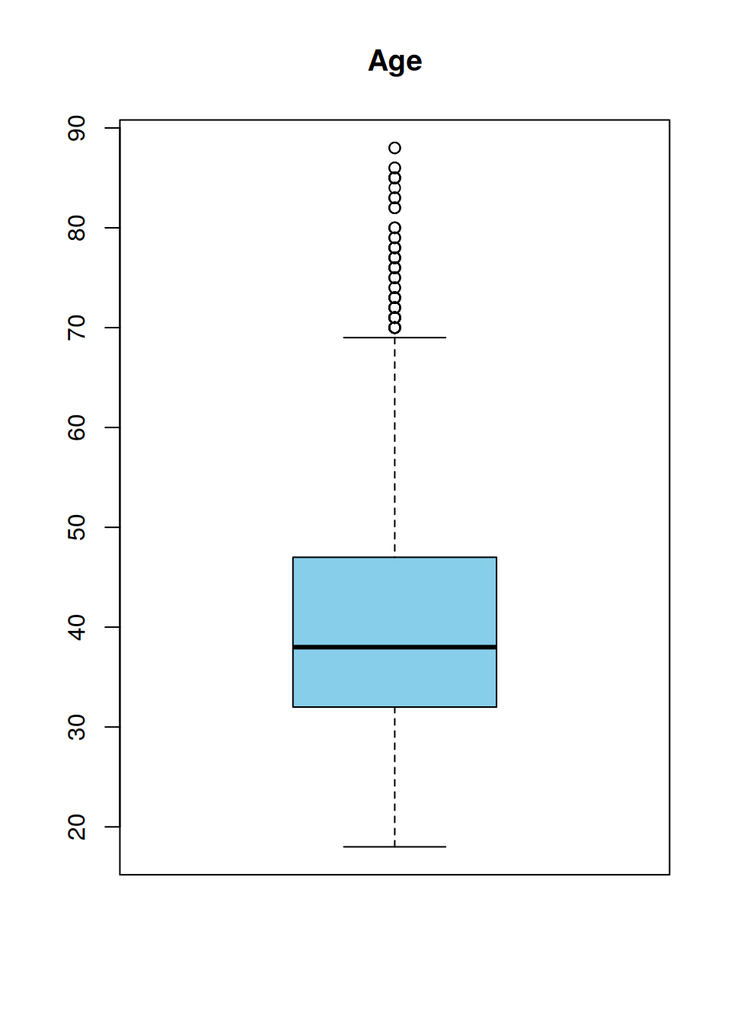

```
## Outlier value in 'Age':
```

```
##  [1] 85 78 71 84 71 72 73 71 85 85 85 78 70 80 78 71 71 71 72 83 77 77 76 75 70
## [26] 76 72 83 82 70 79 82 71 88 79 88 74 73 71 76 70 75 78 70 80 73 70 75 79 76
## [51] 73 71 78 76 71 78 72 70 77 72 85 77 70 73 71 80 74 70 77 70 83 82 85 86 86
## [76] 73 71 80 77 70 72 71 71 70
```

**2. Duration**

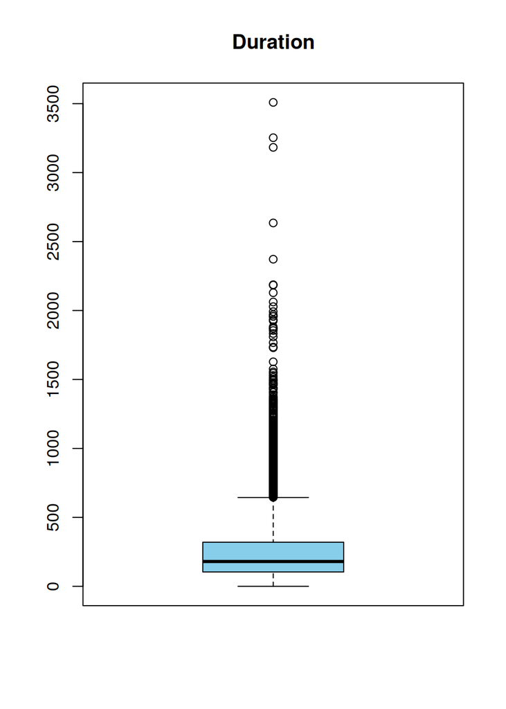

```
## Outlier value in 'Duration':
```

[output not shown]

[output cut: 25 more lines]

**3. Campaign**

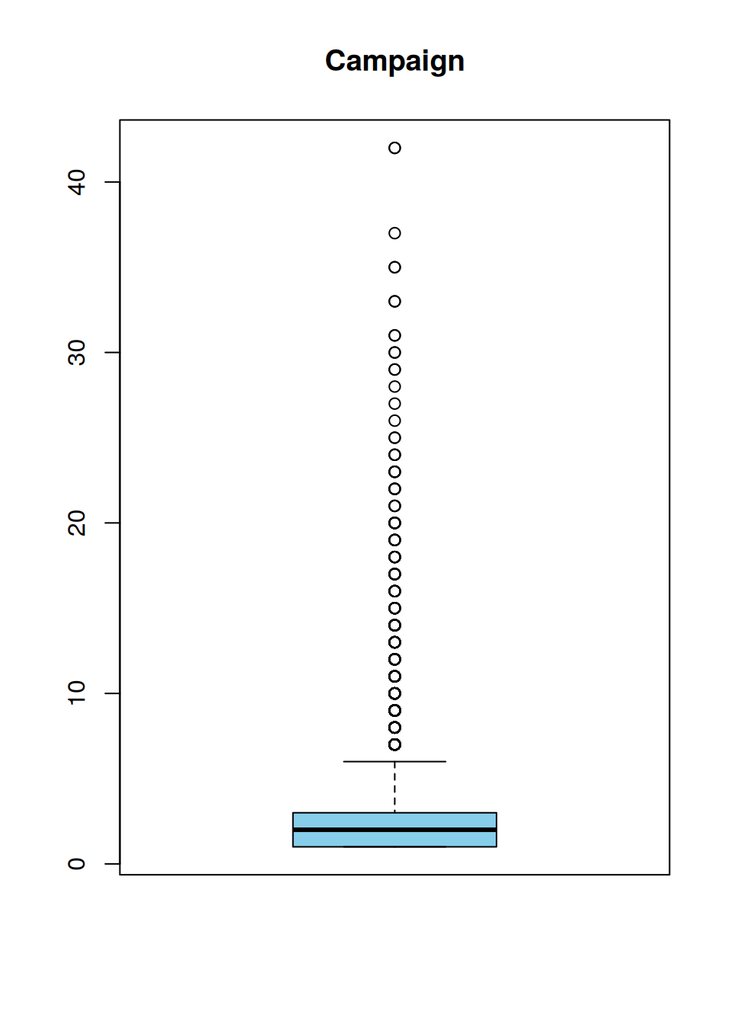

```
## Outlier value in 'Campaign':
```

[output not shown]

**4. P Days**

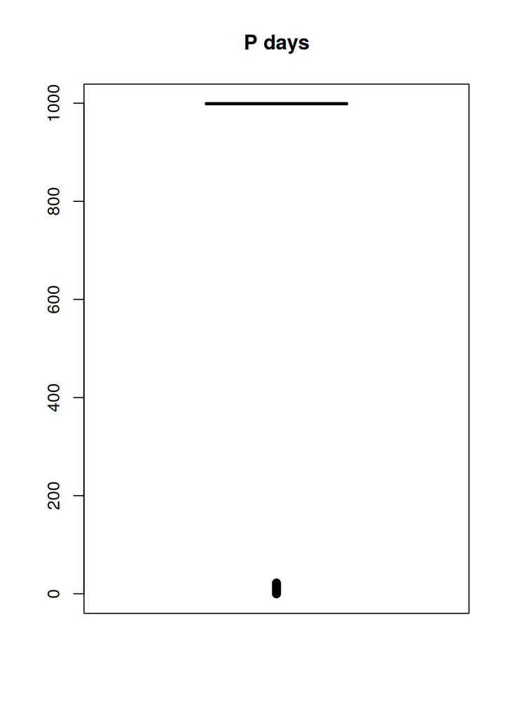

```
## Outlier value in 'P Days':
```

[output not shown]

### B. Handle the issues

```
##       age                   job           marital
##  Min.   :18.00   admin.       :1716   divorced: 677
##  1st Qu.:31.00   blue-collar  :1152   married :3415
##  Median :37.00   technician   :1051   single  :1947
##  Mean   :38.82   services     : 585
##  3rd Qu.:45.00   management   : 480
##  Max.   :88.00   self-employed: 220
##                  (Other)      : 835
##             education_level default   housing     loan           contact
##  basic              :1570   no:6039   no :2715   no :5106   cellular :4027
##  high.school        :1503             yes:3324   yes: 933   telephone:2012
##  professional.course: 827
##  university.degree  :2139
##
##
##
##      month      day_of_week call_duration       campaign
##  may    :1933   fri:1153    Min.   :   0.0   Min.   : 1.000
##  jul    :1063   mon:1215    1st Qu.: 104.0   1st Qu.: 1.000
##  aug    : 887   thu:1263    Median : 181.0   Median : 2.000
##  jun    : 727   tue:1208    Mean   : 259.8   Mean   : 2.505
##  nov    : 647   wed:1200    3rd Qu.: 319.0   3rd Qu.: 3.000
##  apr    : 440               Max.   :2372.0   Max.   :42.000
##  (Other): 342
##          last_contacted_days_ago past_contacts_count        poutcome
##  Not Contacted       :5778       Min.   :0.0000      failure    : 676
##  Previously Contacted: 261       1st Qu.:0.0000      nonexistent:5126
##                                  Median :0.0000      success    : 237
##                                  Mean   :0.1947
##                                  3rd Qu.:0.0000
##                                  Max.   :6.0000
##
##  subscribed days_since_last_contact
##  no :5236   Min.   : 0.000
##  yes: 803   1st Qu.: 3.000
##             Median : 6.000
##             Mean   : 6.218
##             3rd Qu.: 7.000
##             Max.   :22.000
##             NA's   :5778
```

### C. Summary statistics and initial exploration

#### Central tendency and variability for numerical column

```
##       age        call_duration       campaign      past_contacts_count
##  Min.   :18.00   Min.   :   0.0   Min.   : 1.000   Min.   :0.0000
##  1st Qu.:31.00   1st Qu.: 104.0   1st Qu.: 1.000   1st Qu.:0.0000
##  Median :37.00   Median : 181.0   Median : 2.000   Median :0.0000
##  Mean   :38.82   Mean   : 259.8   Mean   : 2.505   Mean   :0.1947
##  3rd Qu.:45.00   3rd Qu.: 319.0   3rd Qu.: 3.000   3rd Qu.:0.0000
##  Max.   :88.00   Max.   :2372.0   Max.   :42.000   Max.   :6.0000
##
##  days_since_last_contact
##  Min.   : 0.000
##  1st Qu.: 3.000
##  Median : 6.000
##  Mean   : 6.218
##  3rd Qu.: 7.000
##  Max.   :22.000
##  NA's   :5778
```

#### A summary table to explore one variable across categories

**Subscription Rate by Education Level**

Subscription Rate by Education Level (%)

| education_level | count | subscribe_rate |
| --- | --- | --- |
| basic | 1570 | 10.32 |
| high.school | 1503 | 12.44 |
| professional.course | 827 | 12.82 |
| university.degree | 2139 | 16.27 |

**Subscription Rate by Contact History**

Subscription Rate by Contact History (%)

| last_contacted_days_ago | count | subscription_rate |
| --- | --- | --- |
| Not Contacted | 5778 | 10.76 |
| Previously Contacted | 261 | 69.35 |

**Subscription Rate by Job Type**

Subscription Rate by Job Type (%)

| job | count | subscription_rate |
| --- | --- | --- |
| admin. | 1716 | 14.51 |
| blue-collar | 1152 | 8.85 |
| entrepreneur | 214 | 11.68 |
| housemaid | 140 | 17.86 |
| management | 480 | 14.58 |
| retired | 212 | 31.60 |
| self-employed | 220 | 13.64 |
| services | 585 | 9.40 |
| student | 121 | 33.06 |
| technician | 1051 | 10.75 |
| unemployed | 148 | 18.24 |

**Subscription Rate by Marital Status**

Subscription Rate by Marital Status (%)

| marital | count | subscription_rate |
| --- | --- | --- |
| divorced | 677 | 12.70 |
| married | 3415 | 12.04 |
| single | 1947 | 15.72 |

## 2. Relationship Analysis

### A. Explore variable relationships

#### Three variables that might influence the campaign outcome

**1.Campaign (Number of Contacts During The Campaign)**

```
##
##  Pearson's product-moment correlation
##
## data:  cleaned_data$campaign and ifelse(cleaned_data$subscribed == "yes", 1, 0)
## t = -5.2144, df = 6037, p-value = 1.905e-07
## alternative hypothesis: true correlation is not equal to 0
## 95 percent confidence interval:
##  -0.09202734 -0.04180916
## sample estimates:
##         cor
## -0.06696065
```

**Interpretation :** The correlation between the number of contact attempts during the campaign and subscription outcome is **very weakly negative** (r = -0.067) and statistically significant (p < 0.001). This suggests that clients who were contacted more frequently may have been marginally less likely to subscribe.

**2. Previously Contacted**

```
##
##  Pearson's product-moment correlation
##
## data:  cleaned_data$past_contacts_count and ifelse(cleaned_data$subscribed == "yes", 1, 0)
## t = 17.77, df = 6037, p-value < 2.2e-16
## alternative hypothesis: true correlation is not equal to 0
## 95 percent confidence interval:
##  0.1988502 0.2467884
## sample estimates:
##       cor
## 0.2229541
```

**Interpretation :** The correlation between the number of past contacts and subscription outcome is **weakly positive** (r = 0.223) and statistically significant (p < 0.001). This suggests that clients with more prior contact were somewhat more likely to subscribe, although the correlation is relatively modest.

**3. Job**

```
##
##                   no  yes
##   admin.        1467  249
##   blue-collar   1050  102
##   entrepreneur   189   25
##   housemaid      115   25
##   management     410   70
##   retired        145   67
##   self-employed  190   30
##   services       530   55
##   student         81   40
##   technician     938  113
##   unemployed     121   27
```

```
##
##  Pearson's Chi-squared test
##
## data:  table(cleaned_data$job, cleaned_data$subscribed)
## X-squared = 144.99, df = 10, p-value < 2.2e-16
```

Subscription by Job Type

| job | yes | no | total | percent |
| --- | --- | --- | --- | --- |
| admin. | 249 | 1467 | 1716 | 14.5 |
| blue-collar | 102 | 1050 | 1152 | 8.9 |
| entrepreneur | 25 | 189 | 214 | 11.7 |
| housemaid | 25 | 115 | 140 | 17.9 |
| management | 70 | 410 | 480 | 14.6 |
| retired | 67 | 145 | 212 | 31.6 |
| self-employed | 30 | 190 | 220 | 13.6 |
| services | 55 | 530 | 585 | 9.4 |
| student | 40 | 81 | 121 | 33.1 |
| technician | 113 | 938 | 1051 | 10.8 |
| unemployed | 27 | 121 | 148 | 18.2 |

**Interpretation :** The highest proportion of subscriptions came from student clients (33.1%), followed by retired individuals(31.6%), while the lowest came from those in blue-collar jobs (8.9%). This suggests that job type may influence clients’ interest or their ability to subscribe.

### B. Feature engineering

#### Create 3 new variables

**1. Age Group**

```
##             job           marital                education_level default
##  admin.       :1716   divorced: 677   basic              :1570   no:6039
##  blue-collar  :1152   married :3415   high.school        :1503
##  technician   :1051   single  :1947   professional.course: 827
##  services     : 585                   university.degree  :2139
##  management   : 480
##  self-employed: 220
##  (Other)      : 835
##  housing     loan           contact         month      day_of_week
##  no :2715   no :5106   cellular :4027   may    :1933   fri:1153
##  yes:3324   yes: 933   telephone:2012   jul    :1063   mon:1215
##                                         aug    : 887   thu:1263
##                                         jun    : 727   tue:1208
##                                         nov    : 647   wed:1200
##                                         apr    : 440
##                                         (Other): 342
##  call_duration       campaign              last_contacted_days_ago
##  Min.   :   0.0   Min.   : 1.000   Not Contacted       :5778
##  1st Qu.: 104.0   1st Qu.: 1.000   Previously Contacted: 261
##  Median : 181.0   Median : 2.000
##  Mean   : 259.8   Mean   : 2.505
##  3rd Qu.: 319.0   3rd Qu.: 3.000
##  Max.   :2372.0   Max.   :42.000
##
##  past_contacts_count        poutcome    subscribed days_since_last_contact
##  Min.   :0.0000      failure    : 676   no :5236   Min.   : 0.000
##  1st Qu.:0.0000      nonexistent:5126   yes: 803   1st Qu.: 3.000
##  Median :0.0000      success    : 237              Median : 6.000
##  Mean   :0.1947                                    Mean   : 6.218
##  3rd Qu.:0.0000                                    3rd Qu.: 7.000
##  Max.   :6.0000                                    Max.   :22.000
##                                                    NA's   :5778
##     age_group
##  Under 30:1288
##  30-50   :3869
##  Over 50 : 882
##
##
##
##
```

**2. Recency Level**

```
##
##                               no  yes
##   Contacted Over a Week Ago   21   40
##   Contacted Within a Week     59  141
##   Never Contacted           5156  622
```

**Interpretation:** Previous contact is one of the strongest signals in the data. Clients who were never contacted before subscribe at about **11%**. Clients contacted in a previous campaign subscribe at roughly **65–70%**, whether the contact was within the last week or longer ago. Follow-ups with warm leads are far more productive than cold calls.

**3. Total Contact Attempts**

```
##             job           marital                education_level default
##  admin.       :1716   divorced: 677   basic              :1570   no:6039
##  blue-collar  :1152   married :3415   high.school        :1503
##  technician   :1051   single  :1947   professional.course: 827
##  services     : 585                   university.degree  :2139
##  management   : 480
##  self-employed: 220
##  (Other)      : 835
##  housing     loan           contact         month      day_of_week
##  no :2715   no :5106   cellular :4027   may    :1933   fri:1153
##  yes:3324   yes: 933   telephone:2012   jul    :1063   mon:1215
##                                         aug    : 887   thu:1263
##                                         jun    : 727   tue:1208
##                                         nov    : 647   wed:1200
##                                         apr    : 440
##                                         (Other): 342
##  call_duration       campaign              last_contacted_days_ago
##  Min.   :   0.0   Min.   : 1.000   Not Contacted       :5778
##  1st Qu.: 104.0   1st Qu.: 1.000   Previously Contacted: 261
##  Median : 181.0   Median : 2.000
##  Mean   : 259.8   Mean   : 2.505
##  3rd Qu.: 319.0   3rd Qu.: 3.000
##  Max.   :2372.0   Max.   :42.000
##
##  past_contacts_count        poutcome    subscribed    age_group
##  Min.   :0.0000      failure    : 676   no :5236   Under 30:1288
##  1st Qu.:0.0000      nonexistent:5126   yes: 803   30-50   :3869
##  Median :0.0000      success    : 237              Over 50 : 882
##  Mean   :0.1947
##  3rd Qu.:0.0000
##  Max.   :6.0000
##
##                    recency_level  total_contact_attempts
##  Contacted Over a Week Ago:  61   Min.   : 1.0
##  Contacted Within a Week  : 200   1st Qu.: 1.0
##  Never Contacted          :5778   Median : 2.0
##                                   Mean   : 2.7
##                                   3rd Qu.: 3.0
##                                   Max.   :42.0
##
```

### C. Interactive visualizations of relationships

**Comparing two categorical variables (Education vs Subscribed)**

[interactive chart not shown]

**Interpretation :** Based on the bar chart that breaks down subscription status by education level, we can observe several key trends. University graduates are the biggest group, and they also subscribe the most. Clients with basic or high school educations are also a big part of the client base, but they exhibit lower subscription rates when compared to those with higher education levels. On the other hand, clients enrolled in professional courses represent the smallest group and don’t subscribe much either.This pattern suggests a positive correlation between education level and the likelihood of subscribing to the offered campaign. But, it’s worth pointing out that the majority of clients, regardless of their education, still didn’t subscribe, highlighting a general trend of low campaign conversion.

**Comparing one numeric and one categorical (Age Group vs Subscription Status)**

[interactive chart not shown]

**Interpretation:** Looking at the bar chart that shows how subscription status varies with age, we can see a few interesting things. The 30-50 age group makes up most of the client base, but again they also happen to be the biggest group of non-subscribers. The “Under 30” and “Over 50” groups are smaller overall, but they seem to subscribe more often than the middle aged group. This suggests that younger and older more senior clients are most likely to subscribe to the campaign than those aged 30–50 years.

**Multi-dimensional chart (Education vs Subscription Rate [Faceted by Age Group])**

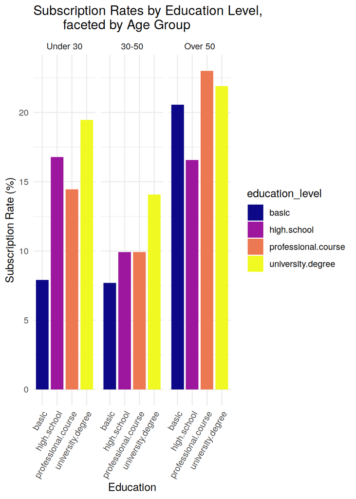

## 3. Insight Storytelling and Recommendations

### A. Data storytelling through visual design

**1. Analysis of Subscription Rates by Education Level Across Different Age Groups**

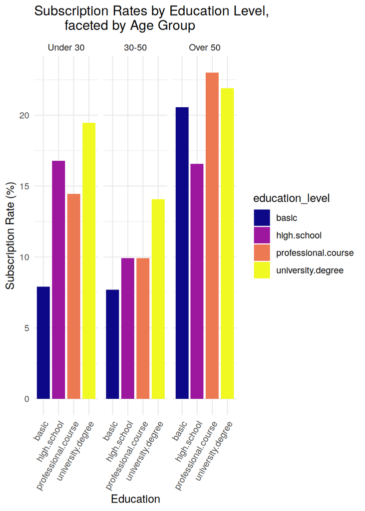

**2. Call Duration’s Impact on Subscription Success**

[interactive chart not shown]

### C. Business Recommendations

1. Recommendations Based on Audience Analysis The analysis shows that certain demographic groups respond much better than others. Therefore, the marketing strategy should shift from a broad, general approach to a more focused one.
- Implement a Targeted Marketing System:
  - Persona A: The Experienced Professional/Retiree: Focus on engaging older, well-educated individuals. The key message for this demographic should highlight lasting value, security, and quality.
  - Persona B: The Ambitious Young Adult Focus on attracting individuals under 30 who have a university or at least finished high school education. The message should emphasize opportunities for advancement and a wide range of benefits. Utilize digital and social media platforms, since they tend to attract a younger crowd.
- Conduct Research on Underperforming Segments: Instead of ignoring the middle-aged (30-50) , conducting surveys may be a good idea to determine whether product is not relevant to them, if the messaging is wrong, or if competitors are better meeting their needs.
2. Recommendations Based on Call Duration Analysis The key insight is that longer, more interactive conversations are linked to successful outcomes. The goal is to not simply just make longer calls, but to improve the quality of the interaction, which naturally leads to more productive conversations. In conclusion, to boost sales, the company needs to change its approach by emphasizing valuable customer interactions. This involves better training for sales agents, focusing on the importance of quality over the number of calls made.